# Regression and Bootstrapping

Juan Carlos Castro

10/21/2018

### Question 1

##### Data-generating equation

```r
set.seed(7)
#data 100 observations
X <- seq(1,5,length.out = 100)
errors <- rnorm(100)
Y <- 3*X + errors

#outlier
X[100] = 20
Y[100] = -20

#models
reg_no_outlier <- lm(Y[1:99] ~ X[1:99])
reg_outlier <- lm(Y ~ X)
```

##### Regression results without outlier

```r
summary(reg_no_outlier)
```

```
##
## Call:
## lm(formula = Y[1:99] ~ X[1:99])
##
## Residuals:
##     Min      1Q  Median      3Q     Max
## -1.7187 -0.6272 -0.0104  0.6235  2.4417
##
## Coefficients:
##             Estimate Std. Error t value Pr(>|t|)
## (Intercept)  0.53659    0.26586   2.018   0.0463 *
## X[1:99]      2.86745    0.08319  34.467   <2e-16 ***
## ---
## Signif. codes:  0 '***' 0.001 '**' 0.01 '*' 0.05 '.' 0.1 ' ' 1
##
## Residual standard error: 0.9558 on 97 degrees of freedom
## Multiple R-squared:  0.9245, Adjusted R-squared:  0.9237
## F-statistic:  1188 on 1 and 97 DF,  p-value: < 2.2e-16
```

##### Regression results with outlier

```r
summary(reg_outlier)
```

```
##
## Call:
## lm(formula = Y ~ X)
##
## Residuals:
##      Min       1Q   Median       3Q      Max
## -24.3019  -2.6673   0.2474   3.3121   7.4247
##
## Coefficients:
##             Estimate Std. Error t value Pr(>|t|)
## (Intercept)   9.6293     0.8254  11.667   <2e-16 ***
## X            -0.2664     0.2197  -1.212    0.228
## ---
## Signif. codes:  0 '***' 0.001 '**' 0.01 '*' 0.05 '.' 0.1 ' ' 1
##
## Residual standard error: 4.496 on 98 degrees of freedom
## Multiple R-squared:  0.01477,    Adjusted R-squared:  0.004722
## F-statistic:  1.47 on 1 and 98 DF,  p-value: 0.2283
```

##### Data visualization

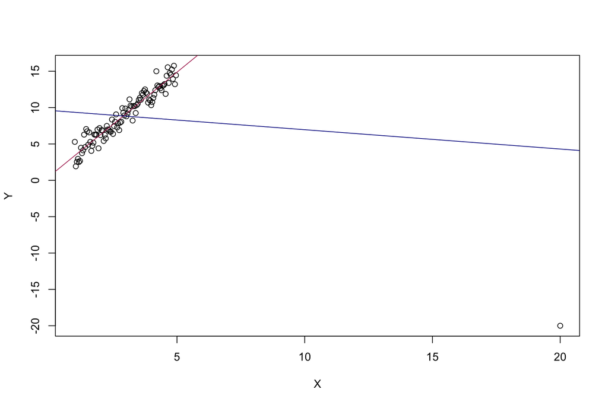

Figure 1. Scatterplot of 100 Y values dependent on the single variable X with coefficient 3 and a normal error term. The 100th observation was modified to simulate the effect of an outlier in a univariate regression model. The red line is the regression fitted to the first 99 observations, and the blue line is fitted to the 100 observations.

Fig. 1 shows how a single outlier would make a regression model completely inaccurate and could provide us with mistaken results. For this reason, one must be careful when fitting linear models as data that has not been cleaned could include outliers that significantly affect the regression.

### Question 2

Loading the data, isolating control group, creating the linear model, and simulating the parameters (betas and sigmas)

```r
#loading packages and data
library(arm)
library(Matching)
data("lalonde")

#isolating control group
lalonde_control <- lalonde[which(lalonde$treat == 0),]

#linear model
predict_re78_control <- lm(re78 ~ age + educ + re74 + re75 + educ*re74 +
                     educ*re75 + age*re74 + age*re75 + re74*re75, data = lalonde_control)

#simulating the parameters
sim_params_re78 <- sim(predict_re78_control, n.sims=10000)
```

Scenario (a)

```r
#age domain
ages <- c(min(lalonde_control$age):max(lalonde_control$age))
length(ages)
```

```
## [1] 39
```

```r
#calculating the medians
med_educ <- median(lalonde_control$educ)
med_re74 <- median(lalonde_control$re74)
med_re75 <- median(lalonde_control$re75)

set.seed(1)

#simulating the predicted values
sim_ys_a <- data.frame()
for (j in 1:39) {
  xs_a <- c(1,ages[j],med_educ, med_re74, med_re75, med_educ*med_re74,
                     med_educ*med_re75, ages[j]*med_re74, ages[j]*med_re75, med_re74*med_re75)
  for (i in 1:10000) {
    betas_a <- sim_params_re78@coef[i,]
    sim_ys_a[i,j] <- sum(xs_a*betas_a) + rnorm(1, 0, sim_params_re78@sigma[i])
  }
}
```

##### Prediction intervals for scenario (a)

```r
#95% prediction intervals for scenario a
pred_intervals_a <- apply(sim_ys_a,2,quantile,probs = c(0.025, 0.975))
pred_intervals_a
```

```
##              V1        V2        V3        V4        V5        V6
## 2.5%  -7138.545 -6456.645 -6919.831 -6828.959 -6976.942 -6802.211
## 97.5% 15124.523 15063.491 15237.280 14870.784 15361.703 14876.843
##              V7        V8        V9       V10       V11       V12
## 2.5%  -7002.084 -6652.174 -6882.848 -7123.635 -6685.944 -6313.004
## 97.5% 14838.298 15281.406 14990.980 15068.588 14949.367 15360.620
##             V13       V14       V15       V16       V17       V18
## 2.5%  -7013.316 -7007.923 -6697.614 -6863.061 -6582.049 -6971.968
## 97.5% 14921.324 15004.064 15189.332 15201.812 15031.661 15168.278
##             V19      V20       V21       V22       V23       V24      V25
## 2.5%  -6685.608 -6764.87 -6705.953 -6842.829 -6752.268 -6805.498 -7008.01
## 97.5% 14969.924 15189.55 15073.845 14972.334 14848.496 15219.663 15013.67
##            V26       V27       V28       V29       V30       V31       V32
## 2.5%  -6863.14 -6674.372 -6873.093 -7186.371 -6872.137 -7046.809 -6947.411
## 97.5% 15237.80 15213.220 15426.033 15075.702 15298.027 15234.978 15617.882
##             V33       V34       V35       V36       V37       V38      V39
## 2.5%  -6797.853 -7288.443 -6965.399 -6965.843 -6872.616 -7002.898 -6994.17
## 97.5% 15332.047 15374.089 15123.508 15236.976 15445.188 15146.975 15687.88
```

##### Visualization

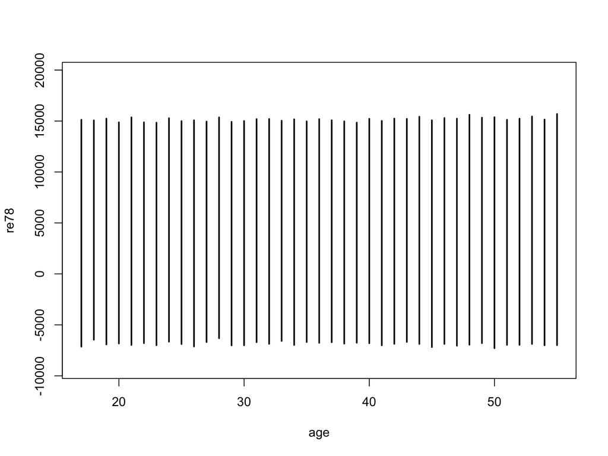

Figure 2. Confidence intervals for re78 predicted for each age in the control group of the lalonde data set. The linear model used age, educ, re74, and re75 as predictors, including some term interactions, and holding educ, re74, and re75 at their medians

Scenario (b)

```r
#calculating the 90% quantiles
quant90_educ <- quantile(lalonde_control$educ, probs = 0.9)
quant90_re74 <- quantile(lalonde_control$re74, probs = 0.9)
quant90_re75 <- quantile(lalonde_control$re75, probs = 0.9)
```

##### Prediction intervals for scenario (b)

```r
#95% prediction intervals for scenario b
set.seed(1)

#simulating the predicted values
sim_ys_b <- data.frame()
for (j in 1:39) {
  xs_b <- c(1,ages[j],quant90_educ, quant90_re74, quant90_re75, quant90_educ*quant90_re74,
                     quant90_educ*quant90_re75, ages[j]*quant90_re74, ages[j]*quant90_re75, quant90_re74*quant90_re75)
  for (i in 1:10000) {
    betas_b <- sim_params_re78@coef[i,]
    sim_ys_b[i,j] <- sum(xs_b*betas_b) + rnorm(1, 0, sim_params_re78@sigma[i])
  }
}

pred_intervals_b <- apply(sim_ys_b, 2, quantile, probs = c(0.025, 0.975))
pred_intervals_b
```

```
##              V1        V2        V3       V4        V5        V6        V7
## 2.5%  -5562.827 -5072.193 -5169.765 -5323.51 -5344.878 -5143.505 -5219.005
## 97.5% 17497.075 17310.417 17273.398 17106.13 17455.654 17168.589 16825.758
##              V8        V9       V10       V11       V12       V13
## 2.5%  -4970.296 -5180.266 -5180.657 -5046.435 -4678.332 -5105.551
## 97.5% 17398.788 17322.256 17080.271 17155.019 17498.794 17207.528
##             V14       V15       V16       V17       V18       V19
## 2.5%  -5276.221 -5012.718 -5165.632 -4908.121 -5204.196 -4938.272
## 97.5% 17165.317 17316.796 17331.647 17171.120 17390.236 17050.961
##             V20       V21       V22       V23       V24       V25
## 2.5%  -4925.475 -4995.525 -5329.978 -5144.707 -5487.776 -5474.594
## 97.5% 17252.636 17396.911 17280.684 17194.691 17470.387 17299.552
##             V26       V27       V28       V29       V30       V31
## 2.5%  -5265.316 -5225.492 -5559.226 -5620.121 -5561.682 -5566.886
## 97.5% 17510.273 17592.035 17770.691 17689.520 17729.828 17724.522
##             V32       V33       V34       V35       V36       V37
## 2.5%  -5606.718 -5625.459 -5978.769 -5927.499 -5995.501 -6405.125
## 97.5% 18029.998 18011.080 18254.204 17926.362 18036.449 18256.643
##             V38      V39
## 2.5%  -6388.451 -6377.91
## 97.5% 18401.213 18688.48
```

##### Plot for (b)

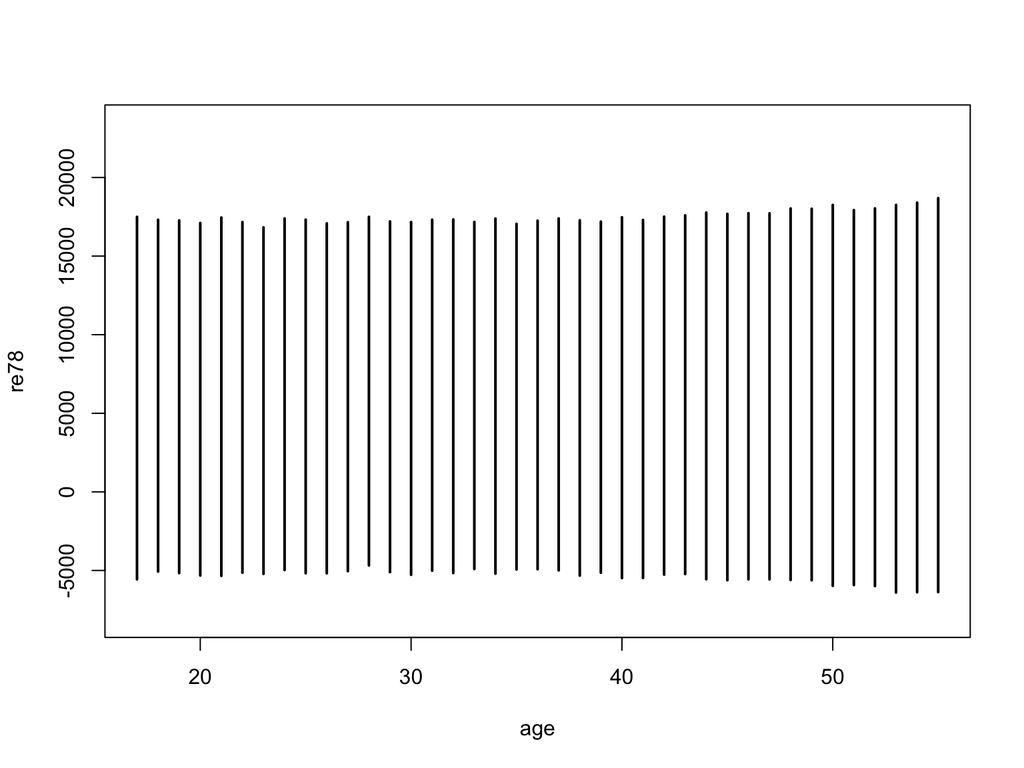

Figure 3. Confidence intervals for re78 predicted for each age in the control group of the lalonde data set. The linear model used age, educ, re74, and re75 as predictors, including some term interactions, and holding educ, re74, and re75 at their 90% quantiles

### Question 3

```r
set.seed(3)
#loading data and packages
library(foreign)
nswdata <- read.dta('/Users/juan/Downloads/nsw.dta')

#my bootstrap function. The obs parameter is a matrix in which the observations are each of the rows. B is the number of samples set as n by default

my_bootstrap <- function(obs, B = nrow(obs)) {
  boot_estimates <- data.frame(cbind(intercept = c(NA),treat = c(NA)))
  for (i in 1:B) {
    inds_samp <- sample(1:nrow(obs), nrow(obs), replace = TRUE)
    one_boot_data <- obs[inds_samp,]
    boot_estimates[i,] <- lm(re78 ~ treat, data = one_boot_data)$coef
  }
  return(boot_estimates)
}

#bootstrapped estimates
nsw_bootstrapped <- my_bootstrap(nswdata)
#bootstrapped 95% confidence interval
bootstrap_intervals <- apply(nsw_bootstrapped, 2, quantile, probs = c(0.025, 0.975))
#analytical 95% confidence interval
analytical_interval <- confint(lm(re78 ~ treat, data = nswdata))
```

##### Bootstrapped 95% confidence interval

```r
t(bootstrap_intervals)
```

```
##                 2.5%    97.5%
## intercept 4560.99557 5642.290
## treat      -67.24301 1826.428
```

##### Analytical 95% confidence interval

```r
analytical_interval
```

```
##                2.5 %   97.5 %
## intercept 4495.60595 5684.491
## treat      -40.52635 1813.134
```

##### Comparison of the treatment coefficient between the bootstrap and the analytical models

```r
rbind(bootstrap = bootstrap_intervals[,2], analytical = analytical_interval[2,])
```

```
##                 2.5%    97.5%
## bootstrap  -67.24301 1826.428
## analytical -40.52635 1813.134
```

##### Data visualization

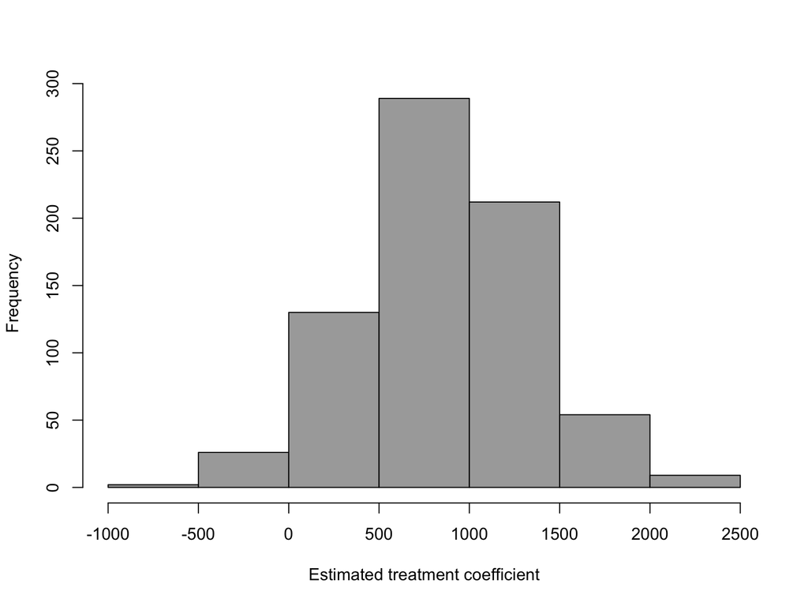

Figure 4. Histogram that shows the distribution of the bootstrapped treatment coefficient from the nsw data

We can see how the bootstrap technique provided us with approximations close to the real confidence intervals (which are also estimates and there’s uncertainty to them), demonstrating the power of bootstrapping. In the next question we will use another metric to evaluate the bootstrap performance.

### Question 4

Function R_squared

```r
R_squared <- function (pred_ys, real_ys) {
  SSE = sum((pred_ys-real_ys)^2)
  SST = sum((real_ys-mean(real_ys))^2)
  return(1-SSE/SST)
}
```

Example using the model from question 3

```r
#predicted re78 by treatment
linmod <- lm(re78 ~ treat, data = nswdata)
pred_ys_re78 <- predict(linmod)

#predicted re78 by treatment using the means of the bootstrapped coefficients calculated in (3)
intercept_boot <- mean(nsw_bootstrapped$intercept)
treat_boot <- mean(nsw_bootstrapped$treat)
pred_ys_re78_bootstrap <- nswdata$treat*treat_boot + intercept_boot
```

R squared of the original linear regression

```r
R_squared(pred_ys_re78, nswdata$re78)
```

```
## [1] 0.004871571
```

R squared using the means of the bootstrapped coefficients

```r
R_squared(pred_ys_re78_bootstrap, nswdata$re78)
```

```
## [1] 0.00486819
```

R squared extracted from the linear model showing the function works

```r
summary(linmod)$r.squared
```

```
## [1] 0.004871571
```

We can see that the model using the means of the bootstrapped coefficients performs very similar to the original linear model when tested using the R squared value

### Question 5

```r
#logistic regression model
logit_nsw <- glm(treat ~ age + education + black + hispanic + married + nodegree + re75, family = "binomial", data = nswdata)

#estimated probabilities
estimated_probs <- predict(logit_nsw, type = "response")
estimated_probs_df <- data.frame(nswdata$treat,estimated_probs)

#getting indexes that will allow separation between treatment and control group
treat_inds <- which(estimated_probs_df$nswdata.treat == 1)
```

##### Visualizations

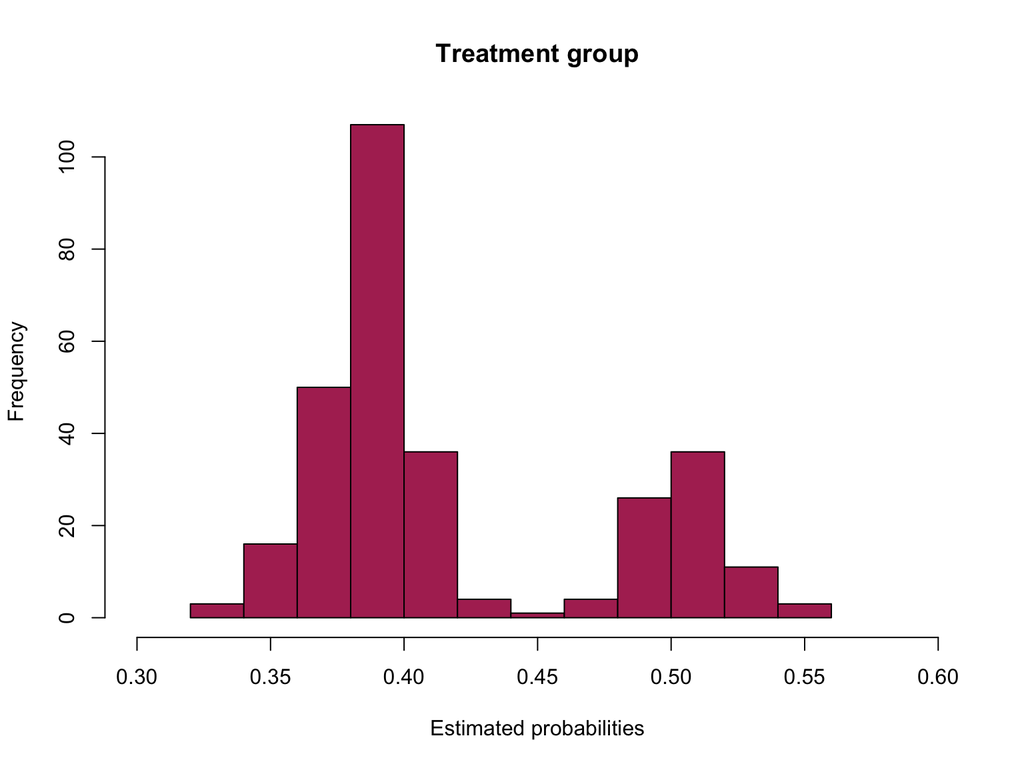

Figure 5. Histogram that shows the distribution of the treatment group’s estimated probabilities of being predicted as part of the treatment group. The probabilities are estimated by a logistic regression model using every parameter as predictor exlcuding re78 and no interaction terms

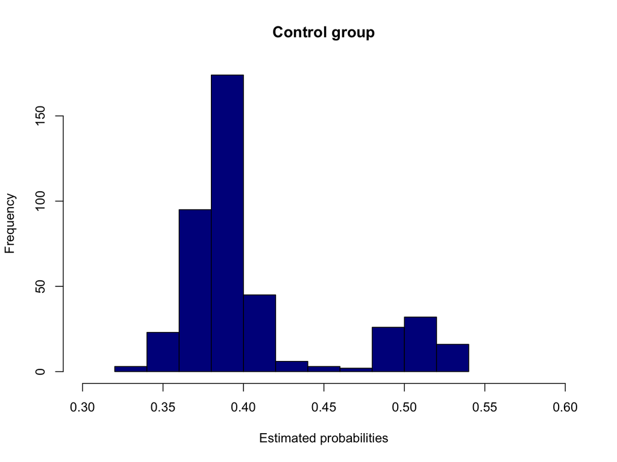

Figure 6. Histogram that shows the distribution of the control group’s estimated probabilities of being predicted as part of the treatment group. The probabilities are estimated by a logistic regression model using every parameter as predictor exlcuding re78 and no interaction terms

We can see how both the control group and the treatment group show similar distributions for the estimated probability. This means that the logistic regression is not effective at separating the control and treatment group. This is an intuitive result as one would expect that treatment is assigned randomly to the members of our sample. A model that would effectively predict belonging to the treatment and control group would tell us that there was some kind of bias when treatment was assigned.

#### Link to gist with code:

https://gist.github.com/jccf12/7ba5f8ca159da4b4f16b95fb8818e416